# Moving Music Mapping investigation

Laura Flenley

2024-12-07

```r
#code for installing packages
install.packages("tidyverse")
install.packages("sf")

#this code will not run unless you change 'eval = TRUE' in the chunk setup: because I already have the packages installed on my computer, so I do not need to install them each time I run the code. They are included so that anyone else looking to run this code can install the packages if they do not have them installed already.

#Packages are collections of code instructions that someone else has helpfully made, that make it easier to do particular things - like a shortcut. I will use the 'tidyverse' package (has code for plotting graphs) and 'sf' package (has code for making maps alongside the tidyverse package).

#Packages need to be 'installed' (aka downloaded) onto a computer once, but not a second time.
```

**Dataset / Map data:** I have downloaded **‘Westminster Parliamentary Constituencies Boundaries July 2024’** from the **Open Geography Portal on the Office for National Statistics** website, since this was chosen as the example when I was being shown how to do this. I should be able to make similar things with a different type of map if that would be more useful.

### Graph of all UK constituencies (all the data)

- I have chosen these colours - can be changed etc.
- Oxfordshire is in green

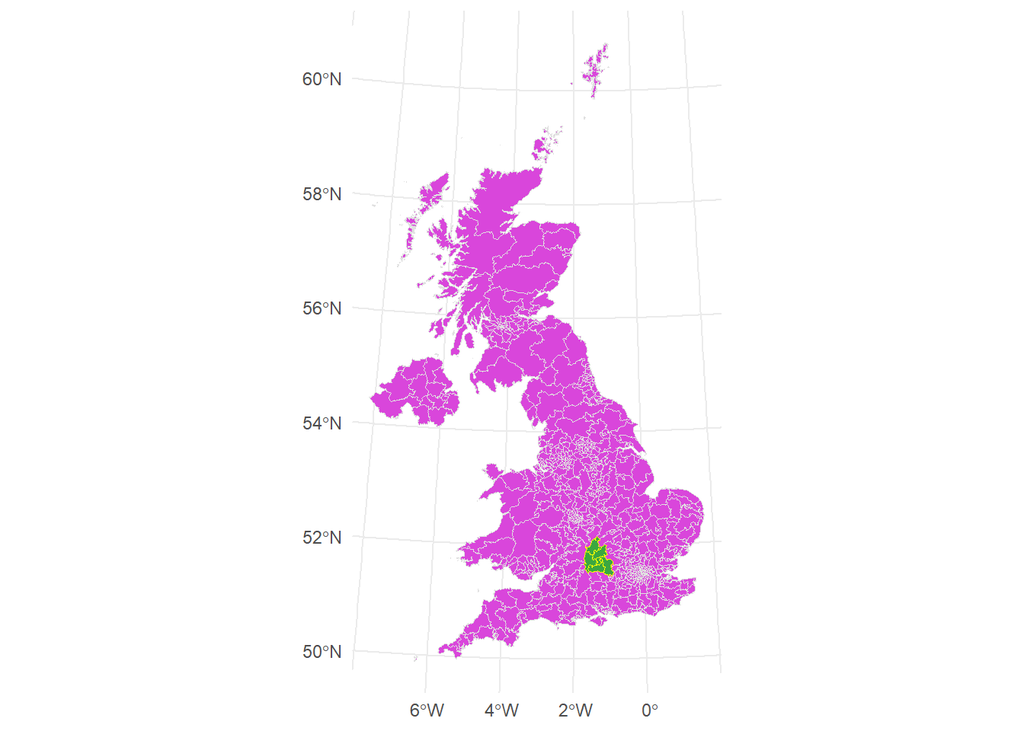

```r
#make a new dataset that is a subset of the entire dataset - containing only oxfordshire constituencies. we will call it 'oxfordshire_sf'
cons_sf %>%
  filter(PCON24NM %in% c("Banbury", "Bicester and Woodstock", "Didcot and Wantage", "Henley and Thame", "Oxford East", "Oxford West and Abingdon", "Witney")) -> oxfordshire_sf

#plot the entire dataset, with oxfordshire in green:
ggplot(cons_sf)+ #plot a graph using cons_sf data (the entire dataset)
  geom_sf(fill = "#d946db", color = "grey88")+ #make everything in the dataset filled in pink, with gray outlines
  geom_sf(data = oxfordshire_sf, fill = "#3BA740", colour = "yellow")+ #add on top: oxfordshire constituencies, filled in green, with yellow outlines
  theme_minimal() #give it a white background
```

### Focussing on Oxfordshire constituencies

(as an example of a smaller map - ideally would include the wider places people travel from rather than just Oxfordshire)

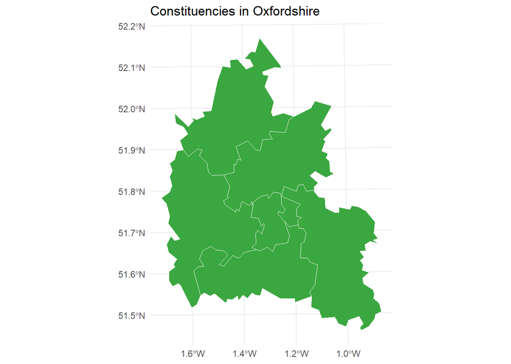

```r
#make oxfordshire dataset into a map
ggplot(oxfordshire_sf) + #using the oxfordshire dataset, make a plot
  geom_sf(fill = "#3BA740", colour = "white")+ #fill everything with green, and include white outlines to constituencies
  labs(title = "Constituencies in Oxfordshire")+ #specify title of graph
  theme_minimal() #give it a white background
```

### …with some details added

- to show how points / locations / lines can be added: I’ve added my house & Dorchester Abbey & connected them.
- I’ve added the electorate of the different constituencies to show how you can colour-code different areas
- you can also overlay different maps together, which I haven’t done here. For instance, I could presumably show more features of the constituencies than just the outlines

```r
#enter here some fancy coding to make the names of constituencies appear
oxfordshire_sf$centroid <- st_centroid(oxfordshire_sf$geometry) #add a column called 'centroid' to our oxfordshire dataset. this column should contain the information about the location of the center of each constituency. We're telling R to calculate these centre locations, using the readymade function st_centroid() and the 'geometry' column that is already in our dataset

centroids <- st_coordinates(oxfordshire_sf$centroid) #make a new data column called centroids. we want it to contain the coordinates of the centroids, which it should obtain from the centroid column we just made before. R will work out the coordinates by using the function st_coordinates()
oxfordshire_sf <- cbind (oxfordshire_sf, centroids) #add the centroids data object we just made to the oxfordshire dataset: now we know the coordinates of the centre of each constituency, so that we can position the constituency names in the middle of each constituency.

#create a new dataset with an added column of names, so the longest names can have line breaks incorporated when we make our plot = looks nicer
oxfordshire_sf_named<-oxfordshire_sf %>% #new dataset is called oxfordshire_sf_named, which starts off as being a copy of oxfordshire_sf
  mutate(name = case_when( #change some parts of the new dataset, if:
    PCON24NM == "Bicester and Woodstock" ~ "Bicester and\nWoodstock",  #if the name is Bicester and Woodstock, change the name to Bicester and \nWoodstock
      #\n indicates a line break: so when we make the graph, the name will not be one very long thin line
    PCON24NM == "Henley and Thame" ~ "Henley and \nThame", #same for this
    PCON24NM == "Oxford West and Abingdon" ~ "Oxford West and\nAbingdon", #same for this
    TRUE ~ PCON24NM #for all the rest of the constituencies: keep the name the same (no linebreak - because I've decided they don't need one)
  ))

#adding dorchester abbey & laura's house
interest_points <- data.frame( #make a new dataframe called interest_points, which will have in it:
  Location = c("Dorchester Abbey", "Laura's house"), #it should have a column called location, with dorchester abbey & laura's house as rows
  lat = c(51.646301, 51.741770), #it should have a column called lat, with these values (latitude - found on google)
  lon = c(-1.167200, -1.258005) #it should have a column called lon, with these values (longitude - found on google)
)

#turn into a new sf object: I don't fully understand what this means, but R needs us to do this if we want to mak e the dataset into a map
interest_points_sf <- st_as_sf(interest_points, coords = c("lon", "lat"), crs = 4326)
  #crs = 4326 states these coordinates we've given it represent longitude & latitude on earth's surface

#convert interest points to same crs as base map otherwise all R-hell breaks loose apparently
interest_points_sf <- st_transform(interest_points_sf, st_crs(oxfordshire_sf_named))
#interest_points_sf

#make a table of just the relevant coordinates of the interest points to add the points to the map
interest_points_coords <- st_coordinates(interest_points_sf) #new table has the coordinates we just put into our interest_points_sf file; but specifically just as numbers rather than some cryptic coding language thing
#interest_points_coords

#lets add electorate to the dataframe oxfordshire_sf_named for fun! yay
Electorate <- c(69943, 70389, 74356,70626,72371,72004,70042) #make a new table with the electorate, listed in the same order as the constituencies appear in the table (alphabetically). this data comes from wikipedia
oxfordshire_sf_named <- cbind(oxfordshire_sf_named, Electorate) #join on the electorate as a column to our master oxfordshire dataset

#define laura's journey distance as the crow flies
journey_line_laura <- st_sfc(st_linestring(interest_points_coords)) #tell it to make a line, using the coordinates of the two points, from our coordinates table
#reassure R that the line has the same CRS as the other datasets (because we already converted it to the right crs before extracting the coordinates)
journey_line_laura <- st_set_crs(journey_line_laura, st_crs(oxfordshire_sf_named))
```

Now we’ve done all the set up, we can code the plot:

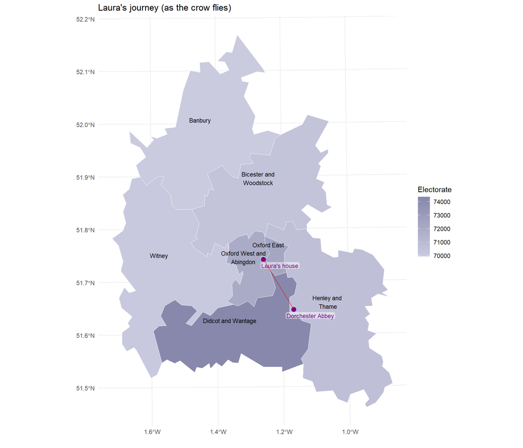

```r
#big lovely plot
ggplot(oxfordshire_sf_named) + #make a plot, using data from oxfordshire_sf_named

  geom_sf(aes(fill = Electorate), color = "white")+ #colour fill the constituencies based on the electorate values, and give them white boundaries

  scale_fill_continuous(name = "Electorate", high = "#8788ab", low = "#cacbdf")+ #higher electorate values should be darker purple, lower values should be lighter purple

  geom_text(aes(x=X, y=Y, label = name), size = 3, colour = "black", nudge_y=+2500, nudge_x=-1500)+ #add the constituency names, using the 'name' column we added (has the line breaks we want). put them text size 3, black text, and move them a bit up & left (so they don't all overlap other text)

  geom_point(data = interest_points_sf, aes(x = interest_points_coords[,1], y = interest_points_coords[,2]), colour = "#770088", size = 3, pch = 19) + #add our points of interest, with size 3 purple dots, using the data from the table we made (interest_points_sf), and getting the coordinates from the coordinates table we made

  geom_label(data = interest_points_sf, aes(x=interest_points_coords[,1], y = interest_points_coords[,2], label = Location), size = 3, nudge_y = -1300, nudge_x = 3500, colour = "#770088", label.padding = unit(0.1, "lines"), label.size=0, alpha = 0.5)+ #add names to the locations: names should be the 'Location' column from the data table interest_points_sf, using the same coordinates as the points (from the coordinates data interest_points_coords). don't put lines round the outside of labels, make the labels a bit transparent, and move them down and right a bit so they don't overlap the actual points

  labs(title = "Laura's journey (as the crow flies)", x="", y="")+ #add a title, and take away the x and y axis names - otherwise it just says X and Y

  theme_minimal()+ #white background

  geom_sf(data=journey_line_laura, colour="red", size = 1) #add the line between the points: from the line dataset we specified; make it size 1, and red.
```

### Some thoughts

- the general gist is you can customise almost everything about them
- There’s a lot more information online about this type of coding so I can look into other ways I could add to this that would be relevant to us
- I can also look for data with more relevant/detailed information than the constituencies dataset I’ve used here
- I don’t like how the constituency names appear.. that’s a work in progress! They’re unreasonably fiddly to move around